[figure not shown]

# PROJECT II : PREDICTING NEURODEGENERATIVE DISEASES

## Realized by Nathalie Fidelita THEODORE (#ID:79)

### As part of the Data scientist program powered by Data Insight

### First cohort (from january 15th to December 15th 2020)

# Table of content

- Introduction
  - Contextual setting
  - Problem
    - Paper's objectives
    - Hypothesis
- Development
  - Methodology
    - Work structure
    - Operational definition of variables
    - Data Collection and Analysis Tools
    - Preparation of the working environmental
      - Installing Libraries
      - Importing modules and packages
      - Importing Parkinsons disease's datasets from Local files
  - Exploratory Data Analysis (EDA)
    - Numerical data anlysis
    - Visual data analysis
      - EDA on the target variable
      - EDA on the features
  - Predictive model
    - Data preprocessing
    - Building a classifier and fitting it to the data
    - Predicting the labels of new data points
    - Computing the accuracy of the classifier's prediction
- Final thoughts
- Sources

# INTRODUCTION

Neurodegenerative diseases, most prevalent in aging populations, is a general term that stands for a bunch of diseases that are related to progressive damage of the nervous system cells, including neurons. Therefore, they affect many of the patient's body activites like balance, movement, breathing, heart function and so one. Most of them are genetic. But few ones can be caused either by human misbehavior like alcoholism or medical condition such as tumor,strokes and viruses. Sometimes the causes can be even unknown. These diseases are so serious and can even be life-threatning. Unfortunately they are incurable.

Nowadays, Neurodegenerative diseases affect millions of people worldwide. The most common are Alzheimer and Parkinson's diseases. In fact, according to a reasearch paper from Harvard University, *"THE CHALLENGE OF NEURODEGENERATIVE DISEASES"* , 5 million Americans suffer from Alzheimer's disease and 1 million from Parkinson. This situation increases the curiosity of many resarchers given that they want to understand the real causes of these diseases in order the treat and prevent them. While who are part of medical field try to find treatments that may help improve symptoms, relieve pain, and increase mobility, those who are evolving in the data science field try to find the perfect model to predict accurately the presence of a neurodegenerative disease in an individual. Earlier this detection is done, better it is for the identification of patients who must take part to clinical trial realized by neuroprotective agents to try and halt disease progression.

As a future data scientist, we must also try to find a way to predict neurodegenerative diseases, as our colleagues have done. That is why, through the Data Insight-supported data scientist program, we need to work on this project **PREDICTING NEURODEGENERATIVE DISEASE**. In the rest of this paper, I will work especially on Parkinson's disease patient dataset created by Max Little of the University of Oxford.

## Objectives

### General objectif

- Predict Neurodegenerative diseases, especially Parkinson's disease

### Specific objectives

- Find out what makes a Parkison patient different from a healthy person
- Build a model that accurately predicts the presence of a neurodegenerative disease in an individual

## Hypothesis

- There is a dependency relationship between the patient's status his fundamental frequency variation
- The patient's status is linked to their 'Signal fractal scaling exponent'

## Methodology

### Work structure

This document is divided into two parts: the first part aims to determine the criteria that differentiate patients with Parkison's disease from healthy people. To do this, we will explore the data set and study the correlation between some explicatives variables(features) and the target variable. The second will focus on the development of a machine learning model to predict Parkison's disease in an individual. In other words, we will train an algorithm to classify an individual's medical information according to whether or not they have the disease.

### Data collection and analysis tools

The dataset used in this paper is the Oxford Parkinson's Disease Detection dataset, a dataset from UCI Machine Learning repository, created by Max Little of the University of Oxford, who recorded the speech signals, in collaboration with the National Centre for Voice and Speech, Denver and Colorado. This dataset consists of a series of biomedical measurements of the voice of 31 people23 with Parkinson's disease (PD).

Our analysis is performed on jupyther notebook.

### Operational definition of variables

This dataset aims to distinguish healthy individuals from patients with Parkinson's disease. Thus, each individual was recorded at least 6 times. Therefore, each column in the table is a particular voice measure, and each row corresponds one of 195 voice recording.

The target variable is **status** which is set to 0 for healthy and 1 for patient with Parkinson's disease patients.

The other variables are:

- **name**: It stands for ASCII subject name followed by recording number
- **MDVP:Fo(Hz)**: Average vocal fundamental frequency
- **MDVP:Fhi(Hz)**: Maximum vocal fundamental frequency
- **MDVP:Flo(Hz)**: Minimum vocal fundamental frequency
- **MDVP:Jitter(%), MDVP:Jitter(Abs), MDVP:RAP, MDVP:PPQ, Jitter:DDPSev**: Seral measures of variation in fundamental frequency
- **MDVP:Shimmer, MDVP:Shimmer(dB), Shimmer:APQ3, Shimmer:APQ5, MDVP:APQ, Shimmer:DDA**: Several measures of variation in amplitude
- **NHR, HNR**: Two measures of ratio of noise to tonal components in the voice
- **RPDE, D2**: Two nonlinear dynamical complexity measures
- **DFA**: Signal fractal scaling exponent
- **spread1, spread2, PPE**: Three nonlinear measures of fundamental frequency variation

P.S: jitter and shimmer are two parameters for measuring the hoarseness of the voice

### Preparation of the working environment

First of all, we need to install the necessary libraries and import some necessary modules and packages.

#### Installing libraries

```python
pip install xgboost
```

#### Importing modules and packages

```python
import pandas as pd
import numpy as np
import seaborn as sns
import matplotlib.pyplot as plt
from sklearn.preprocessing import MinMaxScaler
from sklearn.model_selection import train_test_split
from sklearn.metrics import accuracy_score
from xgboost import XGBClassifier
```

#### Importing Parkinsons disease's datasets from Local files

We need to load the training dataset into a DataFrame

```python
# Load the dataset
dataset=pd.read_csv('parkinsons.data')
```

## Exploratory data analysis

### Numerical data analysis

Let's check out the dataset and do some Exploratory data analysis in order to understand the structure of our data. To do so, we use pandas head(), info() and describe() methods.

```python
#Preview the dataset
print(dataset.head(3))
```

```
             name  MDVP:Fo(Hz)  MDVP:Fhi(Hz)  MDVP:Flo(Hz)  MDVP:Jitter(%)  \
0  phon_R01_S01_1      119.992       157.302        74.997         0.00784
1  phon_R01_S01_2      122.400       148.650       113.819         0.00968
2  phon_R01_S01_3      116.682       131.111       111.555         0.01050

   MDVP:Jitter(Abs)  MDVP:RAP  MDVP:PPQ  Jitter:DDP  MDVP:Shimmer  ...  \
0           0.00007   0.00370   0.00554     0.01109       0.04374  ...
1           0.00008   0.00465   0.00696     0.01394       0.06134  ...
2           0.00009   0.00544   0.00781     0.01633       0.05233  ...

   Shimmer:DDA      NHR     HNR  status      RPDE       DFA   spread1  \
0      0.06545  0.02211  21.033       1  0.414783  0.815285 -4.813031
1      0.09403  0.01929  19.085       1  0.458359  0.819521 -4.075192
2      0.08270  0.01309  20.651       1  0.429895  0.825288 -4.443179

    spread2        D2       PPE
0  0.266482  2.301442  0.284654
1  0.335590  2.486855  0.368674
2  0.311173  2.342259  0.332634

[3 rows x 24 columns]
```

```python
#Summarize the data (1)
print(dataset.info())
```

```
<class 'pandas.core.frame.DataFrame'>
RangeIndex: 195 entries, 0 to 194
Data columns (total 24 columns):
name                195 non-null object
MDVP:Fo(Hz)         195 non-null float64
MDVP:Fhi(Hz)        195 non-null float64
MDVP:Flo(Hz)        195 non-null float64
MDVP:Jitter(%)      195 non-null float64
MDVP:Jitter(Abs)    195 non-null float64
MDVP:RAP            195 non-null float64
MDVP:PPQ            195 non-null float64
Jitter:DDP          195 non-null float64
MDVP:Shimmer        195 non-null float64
MDVP:Shimmer(dB)    195 non-null float64
Shimmer:APQ3        195 non-null float64
Shimmer:APQ5        195 non-null float64
MDVP:APQ            195 non-null float64
Shimmer:DDA         195 non-null float64
NHR                 195 non-null float64
HNR                 195 non-null float64
status              195 non-null int64
RPDE                195 non-null float64
DFA                 195 non-null float64
spread1             195 non-null float64
spread2             195 non-null float64
D2                  195 non-null float64
PPE                 195 non-null float64
dtypes: float64(22), int64(1), object(1)
memory usage: 36.6+ KB
None
```

```python
#Summarize the data (2)
print(dataset.describe())
```

```
       MDVP:Fo(Hz)  MDVP:Fhi(Hz)  MDVP:Flo(Hz)  MDVP:Jitter(%)  \
count   195.000000    195.000000    195.000000      195.000000
mean    154.228641    197.104918    116.324631        0.006220
std      41.390065     91.491548     43.521413        0.004848
min      88.333000    102.145000     65.476000        0.001680
25%     117.572000    134.862500     84.291000        0.003460
50%     148.790000    175.829000    104.315000        0.004940
75%     182.769000    224.205500    140.018500        0.007365
max     260.105000    592.030000    239.170000        0.033160

       MDVP:Jitter(Abs)    MDVP:RAP    MDVP:PPQ  Jitter:DDP  MDVP:Shimmer  \
count        195.000000  195.000000  195.000000  195.000000    195.000000
mean           0.000044    0.003306    0.003446    0.009920      0.029709
std            0.000035    0.002968    0.002759    0.008903      0.018857
min            0.000007    0.000680    0.000920    0.002040      0.009540
25%            0.000020    0.001660    0.001860    0.004985      0.016505
50%            0.000030    0.002500    0.002690    0.007490      0.022970
75%            0.000060    0.003835    0.003955    0.011505      0.037885
max            0.000260    0.021440    0.019580    0.064330      0.119080

       MDVP:Shimmer(dB)  ...  Shimmer:DDA         NHR         HNR      status  \
count        195.000000  ...   195.000000  195.000000  195.000000  195.000000
mean           0.282251  ...     0.046993    0.024847   21.885974    0.753846
std            0.194877  ...     0.030459    0.040418    4.425764    0.431878
min            0.085000  ...     0.013640    0.000650    8.441000    0.000000
25%            0.148500  ...     0.024735    0.005925   19.198000    1.000000
50%            0.221000  ...     0.038360    0.011660   22.085000    1.000000
75%            0.350000  ...     0.060795    0.025640   25.075500    1.000000
max            1.302000  ...     0.169420    0.314820   33.047000    1.000000

             RPDE         DFA     spread1     spread2          D2         PPE
count  195.000000  195.000000  195.000000  195.000000  195.000000  195.000000
mean     0.498536    0.718099   -5.684397    0.226510    2.381826    0.206552
std      0.103942    0.055336    1.090208    0.083406    0.382799    0.090119
min      0.256570    0.574282   -7.964984    0.006274    1.423287    0.044539
25%      0.421306    0.674758   -6.450096    0.174351    2.099125    0.137451
50%      0.495954    0.722254   -5.720868    0.218885    2.361532    0.194052
75%      0.587562    0.761881   -5.046192    0.279234    2.636456    0.252980
max      0.685151    0.825288   -2.434031    0.450493    3.671155    0.527367

[8 rows x 23 columns]
```

Through the numerical data analysis that was done previously, we noticed the dataset has:

- No missing values
- 195 rows and 24 columns
- 22 columns with dtype float64, 1 column with dtype int64 and 1 column with dtype object

### Visual data analysis

Now that we know more about our data and check out some statistics, let's visualize them with seaborn package

#### EDA on target variable

```
The percentage of healthy people is 25
The percentage of patient with Parkinson's disease is 75
```

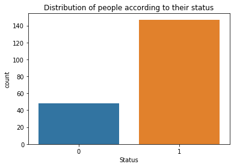

```python
# Bar plot of the target variable 'status'
sns.countplot(x= 'status', data = dataset)
plt.xlabel('Status')
plt.ylabel('count')
plt.title('Distribution of people according to their status')

# Percentage of healthy people and patient with parkinson's disease
a = (dataset [dataset['status'] == 1]).shape[0]
b = (dataset [dataset['status'] == 0]).shape[0]
healthy_people = round(b*100/(a+b))
patient_withpd =  round(a*100/(a+b))
print ('The percentage of healthy people is {}'.format(healthy_people))
print ( "The percentage of patient with Parkinson's disease is {}".format(patient_withpd))
```

There are more people with parkinson's disease than healthy people

#### EDA on features

##### spread1

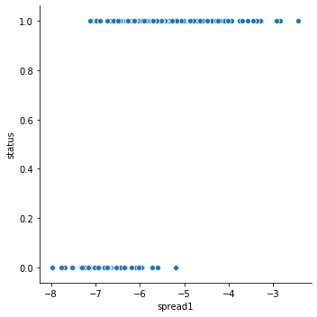

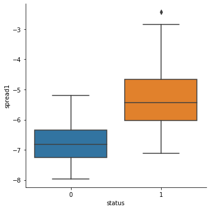

```python
sns.relplot(x="spread1" ,y='status',data=dataset, kind="scatter")
plt.show()

sns.catplot(x='status', y='spread1', kind='box', data=dataset)
```

The highest measure of spread1 is observed in patients with Parkinson's disease than to healthy people and the lowest measure of spread1 tend to belong to healthy people than to patient with Parkinson's disease.

##### spread2

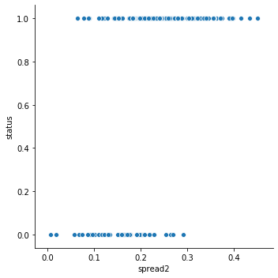

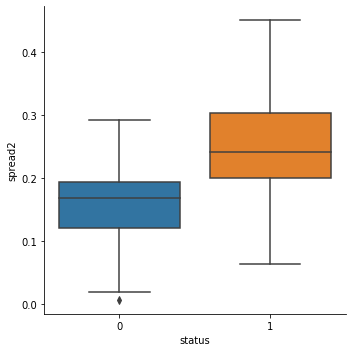

```python
sns.relplot(x="spread2" ,y='status',data=dataset, kind="scatter")
plt.show()

sns.catplot(x='status', y='spread2', kind='box', data=dataset)
```

The highest measure of spread2 tend to belong to Parkinson Positive cases than to Negative cases and the lower measure of spread2 tend to belong to healthy people than toParkinson Positive cases.

##### PPE

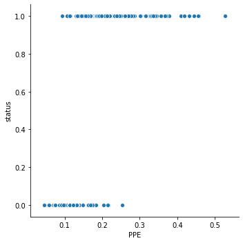

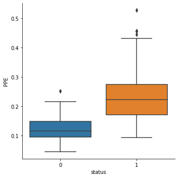

```python
sns.relplot(x="PPE" ,y='status',data=dataset, kind="scatter")
plt.show()

sns.catplot(x='status', y='PPE', kind='box', data=dataset)
```

We noticed that the highest measure of PPE tend to belong to Parkinson Positive cases than to Negative ones

##### DFA

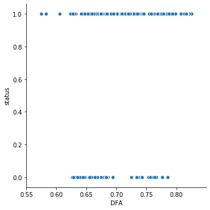

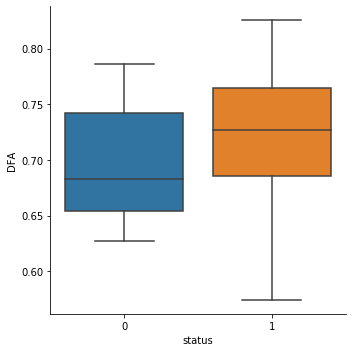

```python
sns.relplot(x="DFA" ,y='status',data=dataset, kind="scatter")
plt.show()

sns.catplot(x='status', y='DFA', kind='box', data=dataset)
```

Let's create the pairplot of the attributes and compute the correlation between data in other to know much more.

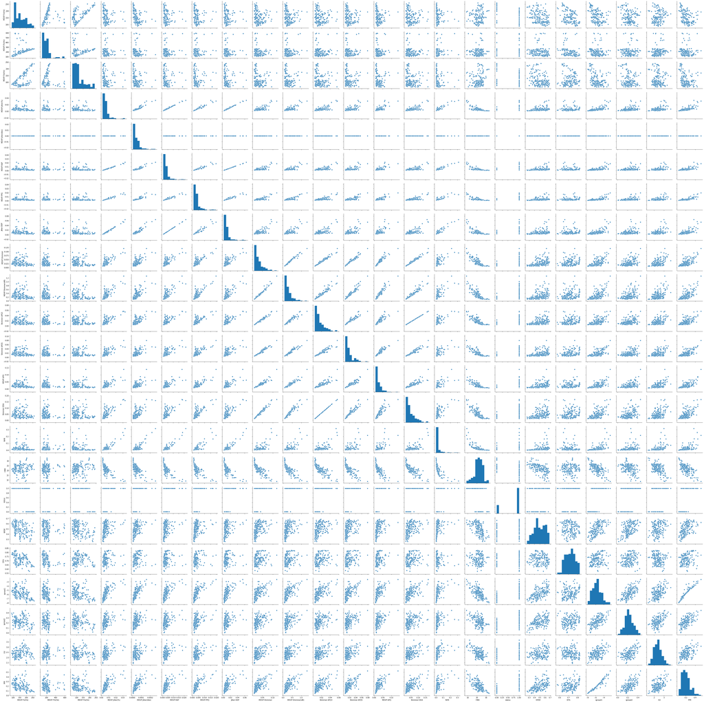

```
MDVP:Fo(Hz)        -0.383535
MDVP:Fhi(Hz)       -0.166136
MDVP:Flo(Hz)       -0.380200
MDVP:Jitter(%)      0.278220
MDVP:Jitter(Abs)    0.338653
MDVP:RAP            0.266668
MDVP:PPQ            0.288698
Jitter:DDP          0.266646
MDVP:Shimmer        0.367430
MDVP:Shimmer(dB)    0.350697
Shimmer:APQ3        0.347617
Shimmer:APQ5        0.351148
MDVP:APQ            0.364316
Shimmer:DDA         0.347608
NHR                 0.189429
HNR                -0.361515
status              1.000000
RPDE                0.308567
DFA                 0.231739
spread1             0.564838
spread2             0.454842
D2                  0.340232
PPE                 0.531039
Name: status, dtype: float64
```

```python
# creating pairplot of the attributes
sns.pairplot(dataset)
plt.show()

#correlation between the features and the target variable
d = dataset.corr()
print(d['status'])
```

There is a:

- moderate positive correlation between the features **PPE**, **spread1**, **spread2** and the target variable **status**
- low positive correlation between the feature **DFA** and the target variable **status**

## Predictive model

Let's build the model that can predict the presence of a neurodegenerative disease in an individual

It is a supervised learning case because there are label present, labeled data.

**"status"** is the target variable that consists of category ( patient with parkinson's disease => 1 and healthy people => 0). Because we want to predict a category for the data, so the learning task is a classification.

### Data preprocessing

Before building models, it is essential to pre-process the data.

First of all, the data set will be divided into features and corresponding labels. Then, the resulting data set will be divided into training and test sets.

P.S: We are going to use 22 characteristics (we left the variable *"name"*),because machine learning algorithms only work on number.

```python
features = dataset.loc[:,dataset.columns!='status'].values[:,1:]
labels=dataset.loc[:,'status'].values
print(features)
print (labels)
```

```
[[119.992 157.302 74.997 ... 0.266482 2.3014419999999998 0.284654]
 [122.4 148.65 113.819 ... 0.33559 2.486855 0.368674]
 [116.682 131.111 111.555 ... 0.311173 2.342259 0.33263400000000004]
 ...
 [174.688 240.005 74.287 ... 0.158453 2.6797720000000003
  0.13172799999999998]
 [198.764 396.961 74.904 ... 0.207454 2.138608 0.123306]
 [214.289 260.277 77.973 ... 0.190667 2.555477 0.148569]]
[1 1 1 1 1 1 1 1 1 1 1 1 1 1 1 1 1 1 1 1 1 1 1 1 1 1 1 1 1 1 0 0 0 0 0 0 1
 1 1 1 1 1 0 0 0 0 0 0 0 0 0 0 0 0 1 1 1 1 1 1 0 0 0 0 0 0 1 1 1 1 1 1 1 1
 1 1 1 1 1 1 1 1 1 1 1 1 1 1 1 1 1 1 1 1 1 1 1 1 1 1 1 1 1 1 1 1 1 1 1 1 1
 1 1 1 1 1 1 1 1 1 1 1 1 1 1 1 1 1 1 1 1 1 1 1 1 1 1 1 1 1 1 1 1 1 1 1 1 1
 1 1 1 1 1 1 1 1 1 1 1 1 1 1 1 1 1 0 0 0 0 0 0 0 0 0 0 0 0 1 1 1 1 1 1 0 0
 0 0 0 0 0 0 0 0 0 0]
```

Before dividing the dataset into training and test sets, let's normalize the data ,so it ranges from -1 and 1, in order to put the features on a similar scale

```python
#Scale the features to between -1 and 1
scaler=MinMaxScaler((-1,1))
x=scaler.fit_transform(features)
y=labels
```

```python
#Split the dataset 80% train and 20% test
x_train,x_test,y_train,y_test=train_test_split(x, y, test_size=0.2, random_state=21)
```

### Building a classifier and fitting it to the data

Given that XGBoost is well known to provide better solutions than other machine learning algorithms, so we going to use its classifier.

```python
'''Train the model'''
#Instantiate a XGBClassifier
model=XGBClassifier()

#fit the classifier to the training set
model.fit(x_train,y_train)
```

```
XGBClassifier(base_score=0.5, booster='gbtree', colsample_bylevel=1,
              colsample_bynode=1, colsample_bytree=1, gamma=0, gpu_id=-1,
              importance_type='gain', interaction_constraints='',
              learning_rate=0.300000012, max_delta_step=0, max_depth=6,
              min_child_weight=1, missing=nan, monotone_constraints='()',
              n_estimators=100, n_jobs=0, num_parallel_tree=1,
              objective='binary:logistic', random_state=0, reg_alpha=0,
              reg_lambda=1, scale_pos_weight=1, subsample=1,
              tree_method='exact', validate_parameters=1, verbosity=None)
```

### Predicting the labels of new data points

Now that our xgbclassifier fit to the training set, it can be used to predict labels of new data points

```python
#predict the test set labels
y_pred=model.predict(x_test)
print(y_pred)
```

```
[1 1 1 1 0 1 1 1 1 1 1 1 0 0 1 1 1 1 1 0 0 0 0 0 1 0 1 1 1 1 1 1 1 1 1 1 1
 0 1]
```

### Computing the accuracy of the classifier's prediction.

Let's measure the performance of our model

```python
# Evaluate and print test-set accuracy
accuracy = accuracy_score(y_test, y_pred)*100
print(round(accuracy,1))
```

```
97.4
```

So, the xgbclassifier has learned from the training set and can predict the presence of Parkinson's disease in an individual with 97.4% accuracy.

# Final thoughts

Throughout the study we noticed:

- a moderate positive correlation between the features **PPE, spread1, spread2** and the target variable **status**
- a low positive correlation between the feature **DFA** and the target variable **status**
- the XGBoost algorithm build a model that can predict the presence of Parkinson's disease in an individual with 97.4% accuracy.

# Sources

[What are Neurodegenerative Diseases and How Do They Affect the Brain?](https://kids.frontiersin.org/article/10.3389/frym.2018.00070)

['Exploiting Nonlinear Recurrence and Fractal Scaling Properties for Voice Disorder Detection', Little MA, McSharry PE, Roberts SJ, Costello DAE, Moroz IM. BioMedical Engineering OnLine 2007, 6:23 (26 June 2007)](https://archive.ics.uci.edu/ml/machine-learning-databases/parkinsons/)

[Introduction to data visualization with seaborn](https://www.datacamp.com/courses/introduction-to-data-visualization-with-seaborn)